# Startup Success Prediction

Programming Languages - Project by Helena Schick

2023-04-28

# 1 Plan

## 1.1 Identify Use Case

The objective of this project is to predict the success of startups. A startup is a new company founded by an entrepreneur with the intent to grow beyond the solo founder according to [wikipedia](https://en.wikipedia.org/wiki/Startup_company). Startups play major role in the economy, as they foster innovation and create employment as they grow. Yet, they face high uncertainty and need to find investors to continue their ideas and expand their potential. This project focuses on the investors to find companies with great potential to invest in and thus being one step ahead of the competition. A business model canvas is used to describe the use case in more detail.

1. Customer Segments: The costumers of this use case are investors that want to investigate the startup landscape quickly and want to make the best possible investment. The investors’ biggest pain is the uncertainty of the investment in a startup. Even with a well-developed business plan and promising market research, there is no guarantee that the startup will be successful. Furthermore, startups are inherently risky ventures. They often have limited operating history and may face significant challenges in scaling up their operations, acquiring customers, and generating revenue. Moreover, investing in a startup requires a significant time commitment. Investors need to research potential opportunities, evaluate business plans, and actively monitor their investments. Their gains include high returns in the case that the startup will be successful. Especially early-stage investors have the opportunity to purchase equity at a low valuation, which can result in a significant return on investment if the company is acquired or goes public. In addition, investing in startups can help diversify an investor’s portfolio. Startups can provide exposure to new market segments that may be difficult to access through traditional investments. Furthermore, some investors may be motivated by the social impact that startups can have. By investing in innovative companies that are addressing social or environmental challenges, investors can support positive change while also generating financial returns.
2. Value Proposition: This projects addresses all of these pain points by providing detailed analysis of many variables former startups to transfer these learnings to new investments. It highlights the most important features of a startup to become successful and predicts whether a startup which is currently operating turns into a success or a failure. The success of a company is defined as the event that gives the company’s founders a large sum of money through the process of M&A (Merger and Acquisition) or an IPO (Initial Public Offering). A company would be considered as failed if it had to be shut down. This minimizes the uncertainty and risk of the investment. As this is provided in one platform, the time commitment and intense research is reduced tremendously. The data can always be extended through more startup data provided by the customers. This has the advantage that possible changes in the successful features are encountered and the use case always provides the latest and most valuable information.
3. Channels: Specific investors will be contacted directly to learn about this startup success prediction and how to purchase it. In addition, the use case will be advertised on business platforms and online newspapers.
4. Customer Relationships: A close customer collaboration will be created, that the investors have the information about startup success prediction and also share information about their past investments that the data is always improving and up to date.
5. Revenue Streams: The startup success prediction can be purchased as a yearly abonnement by investors. They can get a reduction of the fee in exchange for startup investment data that can be incorporated in the analysis and prediction.
6. Key Activities: The most important activity is always having a well optimized classification model for the startup success prediction. Another key activity is the data analysis that is used as a base for the prediction model. The third activity is to create a good user experience to visualize the key learnings and recommendations.
7. Key Resources: The project is conducted by Helena Schick. Jan Kirenz can be consulted for advice.
8. Key Partnerships: The key partnerships are with the customers as well, as they provide data to improve the model.
9. Cost Structure: There are currently no costs, as this is done volunatarily on behalf of the module “Programming Languages for Data Science”.

## 1.2 Frame Problem

We are investigating the characteristics of startups Because we want to find out, if a startup will be successful In order to decide to invest in it or not.

We want the model to classify the status of a startup Our ideal outcome is “acquired”, which means that the startup was successful In order to reduce the uncertainty in startup investments.

## 1.4 Define Metrics

Our success metrics are accuracy (percentage of startups that the model correctly predicts as successful or unsuccessful) and precision (indicates that the model is making fewer false positive predictions). Our key results for the success metrics are an accuracy and precision of more than 80%. Our project is deemed a failure, if the accuracy and precision are lower than 80%.

# 2 Data

## 2.1 Data Ingestion

### 2.1.1 Prepare Environment

At first, R is set up.

Then the necessary libraries for the entire notebook are activated and have been installed before.

```r
library(tidyverse)
library(conflicted)
library(dplyr)
library(visdat)
library(rsample)
library(tidymodels)
library(skimr)
library(purrr)
library(GGally)
```

```r
library(DBI)
library(maps)
library(mapproj)
library(caret)
library(xgboost)
library(kknn)
library(vip)
library(tidy.outliers)
```

### 2.1.2 Import Data

Currently csv upload, could chnage this to upload from a database.

```r
path <- "/Users/helena.schick/Documents/GitHub/r-sql-startup-success/startup data.csv"

df <- read_csv(path)
```

### 2.1.3 Data Structure

Now, we’re having a first look at the data, including the column names, data types and their content.

```r
glimpse(df)
```

```
## Rows: 923
## Columns: 49
## $ `Unnamed: 0`             <dbl> 1005, 204, 1001, 738, 1002, 379, 195, 875, 16…
## $ state_code               <chr> "CA", "CA", "CA", "CA", "CA", "CA", "CA", "CA…
## $ latitude                 <dbl> 42.35888, 37.23892, 32.90105, 37.32031, 37.77…
## $ longitude                <dbl> -71.05682, -121.97372, -117.19266, -122.05004…
## $ zip_code                 <chr> "92101", "95032", "92121", "95014", "94105", …
## $ id                       <chr> "c:6669", "c:16283", "c:65620", "c:42668", "c…
## $ city                     <chr> "San Diego", "Los Gatos", "San Diego", "Cuper…
## $ `Unnamed: 6`             <chr> NA, NA, "San Diego CA 92121", "Cupertino CA 9…
## $ name                     <chr> "Bandsintown", "TriCipher", "Plixi", "Solidco…
## $ labels                   <dbl> 1, 1, 1, 1, 0, 0, 1, 1, 1, 1, 1, 0, 0, 1, 1, …
## $ founded_at               <chr> "1/1/2007", "1/1/2000", "3/18/2009", "1/1/200…
## $ closed_at                <chr> NA, NA, NA, NA, "10/1/2012", "2/15/2009", NA,…
## $ first_funding_at         <chr> "4/1/2009", "2/14/2005", "3/30/2010", "2/17/2…
```

[output cut: 36 more lines]

The column `Unnamed: 0` seems to be some kind of id, but has no further value and will be deleted. Labels and avg_participants cannot be understood without further context. `Unnamed: 6` is a combination of the zip code and city and thus redundant and will be deleted. The redundancy also accounts for state_code.1 and object_id. For categories and states there are each a categorical variable and several one hot encoded ones. All are kept at this point, because the categorical is better for visualizations and data understanding, but the one hot encoded ones are needed for the classification model. The variables are described in more detail:

[output not shown]

To understand the ratio of numerical to categorical variables and view the amount of null values in the dataframe, we visualize it.

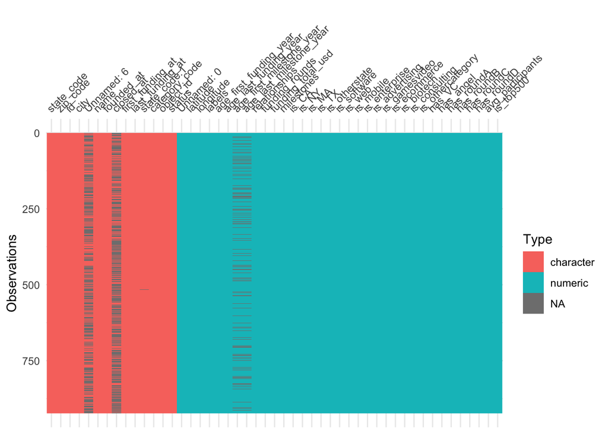

```r
vis_dat(df)
```

The majority of variables are numeric. There are many null values in the columns Unnamed:6, which will be deleted anyways, as well as closed_at, because this only applies, if the startup has failed, and age_first_milestone and age_last_milestone. We are keeping these two variables to get some insights about those startups that have them available.

### 2.1.4 Data Corrections

At first, all variables of the data type character are turned into factors. This has the advantages of memory efficiency, ordering, handling of missing values, visualization and improved functionality.

```r
# convert all character variables to factors
df <-
  df %>%
  mutate(across(where(is.character), as.factor))
```

Secondly, the variables taht represent dates are turned into the data type date.

```r
# convert all date variables to actual dates
df$founded_at <-
  as.Date(df$founded_at, format = "%m/%d/%Y")
df$closed_at <-
  as.Date(df$closed_at, format = "%m/%d/%Y")
df$first_funding_at <-
  as.Date(df$first_funding_at, format = "%m/%d/%Y")
df$last_funding_at <-
  as.Date(df$last_funding_at, format = "%m/%d/%Y")
```

In the end, unnecessary varibales are removed.

```r
# remove unnecessary variables
df <-
  dplyr::select(df, -`Unnamed: 0`, -`Unnamed: 6`, -state_code.1, -object_id, -labels, -avg_participants)
```

### 2.1.5 Variable List

For easier usage in data splitting, several variable lists are created.

```r
# define outcome variable as y_label
y_label <- 'status'

# select feature names
features <-
  df %>%
  select(-all_of(y_label)) %>%
  names()

# create feature data for data splitting
X <-
  df %>%
  select(all_of(features))

# list of numeric feature names
feat_num <-
  X %>%
  select(where(is.numeric)) %>%
  names()

# list of categorical feature names
feat_cat <-
  X %>%
  select(!where(is.numeric)) %>%
  names()

# create response for data splitting
y <-
  df %>%
  select(all_of(y_label))
```

## 2.2 Data Splitting

### 2.2.1 Train and Test Split

The dataframe is split into a training and test set. The training set will be used to train the model and the the test set is used to verify how well the model performs with newly added data.

```r
# Fix the random numbers by setting the seed
# This enables the analysis to be reproducible
set.seed(42)

# Put 3/4 of the data into the training set
data_split <- initial_split(df,
                           prop = 3/4,
                           strata = status,
                           breaks = 4)

# Create dataframes for the two sets:
train_data <- training(data_split)
test_data <- testing(data_split)
```

### 2.2.2 Data Exploration Set

A copy of the training data is created for the data exploration to not alter the actual training data.

```r
df_train <- train_data
```

## 2.3 Analyze Data

Data analysis is done through R and SQL. It gives insights in the distribution of each feature, as well as patterns and correlations. At first the scales of each feature are analyzed, including the quartiles, mean and median. Using skim, this also includes a rough histogram.

```r
skim(df_train)
```

Data summary

| Name | df_train |
| --- | --- |
| Number of rows | 691 |
| Number of columns | 43 |
| _______________________ |  |
| Column type frequency: |  |
| Date | 4 |
| factor | 7 |
| numeric | 32 |
| ________________________ |  |
| Group variables | None |

**Variable type: Date**

| skim_variable | n_missing | complete_rate | min | max | median | n_unique |
| --- | --- | --- | --- | --- | --- | --- |
| founded_at | 0 | 1.00 | 1984-01-01 | 2013-04-16 | 2006-01-01 | 182 |
| closed_at | 442 | 0.36 | 2001-01-01 | 2013-10-30 | 2012-03-06 | 164 |
| first_funding_at | 0 | 1.00 | 2000-01-01 | 2013-11-19 | 2007-09-01 | 473 |
| last_funding_at | 0 | 1.00 | 2001-02-26 | 2013-11-19 | 2009-12-29 | 534 |

**Variable type: factor**

| skim_variable | n_missing | complete_rate | ordered | n_unique | top_counts |
| --- | --- | --- | --- | --- | --- |
| state_code | 0 | 1 | FALSE | 31 | CA: 365, NY: 77, MA: 63, WA: 34 |
| zip_code | 0 | 1 | FALSE | 319 | 941: 26, 941: 19, 950: 15, 941: 14 |
| id | 0 | 1 | FALSE | 690 | c:2: 2, c:1: 1, c:1: 1, c:1: 1 |
| city | 0 | 1 | FALSE | 184 | San: 95, New: 65, Mou: 33, Pal: 27 |
| name | 0 | 1 | FALSE | 690 | Red: 2, #wa: 1, 41s: 1, Abo: 1 |
| category_code | 0 | 1 | FALSE | 35 | sof: 117, web: 111, mob: 56, ent: 53 |
| status | 0 | 1 | FALSE | 2 | acq: 447, clo: 244 |

**Variable type: numeric**

| skim_variable | n_missing | complete_rate | mean | sd | p0 | p25 | p50 | p75 | p100 | hist |
| --- | --- | --- | --- | --- | --- | --- | --- | --- | --- | --- |
| latitude | 0 | 1.00 | 38.58 | 3.86 | 25.75 | 37.39 | 37.78 | 40.73 | 5.934e+01 | ▁▇▅▁▁ |
| longitude | 0 | 1.00 | -103.57 | 22.66 | -122.73 | -122.20 | -118.35 | -77.39 | 1.806e+01 | ▇▅▁▁▁ |
| age_first_funding_year | 0 | 1.00 | 2.17 | 2.46 | -9.05 | 0.56 | 1.34 | 3.49 | 2.190e+01 | ▁▇▃▁▁ |
| age_last_funding_year | 0 | 1.00 | 3.88 | 2.95 | -9.05 | 1.59 | 3.50 | 5.56 | 2.190e+01 | ▁▇▇▁▁ |
| age_first_milestone_year | 112 | 0.84 | 2.97 | 2.93 | -14.17 | 0.91 | 2.58 | 4.57 | 2.468e+01 | ▁▃▇▁▁ |
| age_last_milestone_year | 112 | 0.84 | 4.66 | 3.14 | -3.88 | 2.41 | 4.39 | 6.69 | 2.468e+01 | ▂▇▂▁▁ |
| relationships | 0 | 1.00 | 7.60 | 6.90 | 0.00 | 3.00 | 5.00 | 10.00 | 5.700e+01 | ▇▂▁▁▁ |
| funding_rounds | 0 | 1.00 | 2.32 | 1.39 | 1.00 | 1.00 | 2.00 | 3.00 | 1.000e+01 | ▇▃▁▁▁ |
| funding_total_usd | 0 | 1.00 | 27859192.08 | 218367604.85 | 11000.00 | 3000000.00 | 10400000.00 | 25065805.50 | 5.700e+09 | ▇▁▁▁▁ |
| milestones | 0 | 1.00 | 1.84 | 1.33 | 0.00 | 1.00 | 2.00 | 3.00 | 8.000e+00 | ▇▇▁▁▁ |
| is_CA | 0 | 1.00 | 0.53 | 0.50 | 0.00 | 0.00 | 1.00 | 1.00 | 1.000e+00 | ▇▁▁▁▇ |
| is_NY | 0 | 1.00 | 0.11 | 0.31 | 0.00 | 0.00 | 0.00 | 0.00 | 1.000e+00 | ▇▁▁▁▁ |
| is_MA | 0 | 1.00 | 0.09 | 0.29 | 0.00 | 0.00 | 0.00 | 0.00 | 1.000e+00 | ▇▁▁▁▁ |
| is_TX | 0 | 1.00 | 0.04 | 0.20 | 0.00 | 0.00 | 0.00 | 0.00 | 1.000e+00 | ▇▁▁▁▁ |
| is_otherstate | 0 | 1.00 | 0.23 | 0.42 | 0.00 | 0.00 | 0.00 | 0.00 | 1.000e+00 | ▇▁▁▁▂ |
| is_software | 0 | 1.00 | 0.17 | 0.38 | 0.00 | 0.00 | 0.00 | 0.00 | 1.000e+00 | ▇▁▁▁▂ |
| is_web | 0 | 1.00 | 0.16 | 0.37 | 0.00 | 0.00 | 0.00 | 0.00 | 1.000e+00 | ▇▁▁▁▂ |
| is_mobile | 0 | 1.00 | 0.08 | 0.27 | 0.00 | 0.00 | 0.00 | 0.00 | 1.000e+00 | ▇▁▁▁▁ |
| is_enterprise | 0 | 1.00 | 0.08 | 0.27 | 0.00 | 0.00 | 0.00 | 0.00 | 1.000e+00 | ▇▁▁▁▁ |
| is_advertising | 0 | 1.00 | 0.07 | 0.25 | 0.00 | 0.00 | 0.00 | 0.00 | 1.000e+00 | ▇▁▁▁▁ |
| is_gamesvideo | 0 | 1.00 | 0.05 | 0.23 | 0.00 | 0.00 | 0.00 | 0.00 | 1.000e+00 | ▇▁▁▁▁ |
| is_ecommerce | 0 | 1.00 | 0.03 | 0.17 | 0.00 | 0.00 | 0.00 | 0.00 | 1.000e+00 | ▇▁▁▁▁ |
| is_biotech | 0 | 1.00 | 0.04 | 0.19 | 0.00 | 0.00 | 0.00 | 0.00 | 1.000e+00 | ▇▁▁▁▁ |
| is_consulting | 0 | 1.00 | 0.00 | 0.05 | 0.00 | 0.00 | 0.00 | 0.00 | 1.000e+00 | ▇▁▁▁▁ |
| is_othercategory | 0 | 1.00 | 0.32 | 0.47 | 0.00 | 0.00 | 0.00 | 1.00 | 1.000e+00 | ▇▁▁▁▃ |
| has_VC | 0 | 1.00 | 0.32 | 0.47 | 0.00 | 0.00 | 0.00 | 1.00 | 1.000e+00 | ▇▁▁▁▃ |
| has_angel | 0 | 1.00 | 0.25 | 0.43 | 0.00 | 0.00 | 0.00 | 0.00 | 1.000e+00 | ▇▁▁▁▂ |
| has_roundA | 0 | 1.00 | 0.51 | 0.50 | 0.00 | 0.00 | 1.00 | 1.00 | 1.000e+00 | ▇▁▁▁▇ |
| has_roundB | 0 | 1.00 | 0.40 | 0.49 | 0.00 | 0.00 | 0.00 | 1.00 | 1.000e+00 | ▇▁▁▁▅ |
| has_roundC | 0 | 1.00 | 0.24 | 0.43 | 0.00 | 0.00 | 0.00 | 0.00 | 1.000e+00 | ▇▁▁▁▂ |
| has_roundD | 0 | 1.00 | 0.09 | 0.29 | 0.00 | 0.00 | 0.00 | 0.00 | 1.000e+00 | ▇▁▁▁▁ |
| is_top500 | 0 | 1.00 | 0.81 | 0.39 | 0.00 | 1.00 | 1.00 | 1.00 | 1.000e+00 | ▂▁▁▁▇ |

**Dates:**

**Categorical features:**

There are startups in 31 states, but CA is most common. Dividing the location up into zip codes, there are 319 different ones in 184 cities. The name and id are almost unique, having one duplicate, which needs to be removed. The startup are in 35 different categories and 2 statuses.

### 2.3.1 SQL Analysis

To use SQL in RStudio a connection is created and the following code cells start with {sql connection=…} instead of {r}.

```r
# Connection to database SQlite
con <- dbConnect(RSQLite::SQLite(), ":memory:")

# Write data "df_train" into database
dbWriteTable(con, "df_train", df_train)

# List tables
dbListTables(con)
```

```
## [1] "df_train"
```

At first, we want to get an overview of the training data and have a look at the first 5 rows.

```sql
SELECT *
FROM df_train
LIMIT 5;
```

5 records

| state_code | latitude | longitude | zip_code | id | city | name | founded_at | closed_at | first_funding_at | last_funding_at | age_first_funding_year | age_last_funding_year | age_first_milestone_year | age_last_milestone_year | relationships | funding_rounds | funding_total_usd | milestones | is_CA | is_NY | is_MA | is_TX | is_otherstate | category_code | is_software | is_web | is_mobile | is_enterprise | is_advertising | … |
| --- | --- | --- | --- | --- | --- | --- | --- | --- | --- | --- | --- | --- | --- | --- | --- | --- | --- | --- | --- | --- | --- | --- | --- | --- | --- | --- | --- | --- | --- | --- |
| CA | 42.35888 | -71.05682 | 92101 | c:6669 | San Diego | Bandsintown | 13514 | NA | 14335 | 14610 | 2.2493 | 3.0027 | 4.6685 | 6.7041 | 3 | 3 | 375000 | 3 | 1 | 0 | 0 | 0 | 0 | music | 0 | 0 | 0 | 0 | 0 | … |
| CA | 37.23892 | -121.97372 | 95032 | c:16283 | Los Gatos | TriCipher | 10957 | NA | 12828 | 14606 | 5.1260 | 9.9973 | 7.0055 | 7.0055 | 9 | 4 | 40100000 | 1 | 1 | 0 | 0 | 0 | 0 | enterprise | 0 | 0 | 0 | 1 | 0 | … |
| CA | 32.90105 | -117.19266 | 92121 | c:65620 | San Diego | Plixi | 14321 | NA | 14698 | 14698 | 1.0329 | 1.0329 | 1.4575 | 2.2055 | 5 | 1 | 2600000 | 2 | 1 | 0 | 0 | 0 | 0 | web | 0 | 1 | 0 | 0 | 0 | … |
| CA | 38.05711 | -122.51374 | 94901 | c:5192 | San Rafael | ClairMail | 12418 | NA | 13019 | 14886 | 1.6466 | 6.7616 | 5.6055 | 7.3616 | 25 | 3 | 34100000 | 3 | 1 | 0 | 0 | 0 | 0 | finance | 0 | 0 | 0 | 0 | 0 | … |
| NY | 40.70276 | -73.98667 | 11201 | c:1491 | Brooklyn | drop.io | 13843 | NA | 13850 | 14732 | 0.0192 | 2.4356 | 0.7945 | 4.3781 | 15 | 3 | 9950000 | 3 | 0 | 1 | 0 | 0 | 0 | education | 0 | 0 | 0 | 0 | 0 | … |

Count all distinct observations with the status “acquired”.

```sql
SELECT DISTINCT COUNT(*)
FROM df_train
WHERE status = 'acquired';
```

1 records

| COUNT(*) |
| --- |
| 447 |

There are 447 startups in the training data that are successful.

Count all distinct observations with the status “closed”.

```sql
SELECT DISTINCT COUNT(*)
FROM df_train
WHERE status = 'closed';
```

1 records

| COUNT(*) |
| --- |
| 244 |

There are 244 startups in the training data that are not successful. Neither of these too small to worry about an uneven distribution for the model performance later on.

Which successful startups receive the most funding? Also providing more information about these companies.

```sql
SELECT name, category_code, state_code, funding_total_usd, age_first_funding_year, funding_rounds
FROM df_train
WHERE status = "acquired"
ORDER BY funding_total_usd DESC
LIMIT 5;
```

5 records

| name | category_code | state_code | funding_total_usd | age_first_funding_year | funding_rounds |
| --- | --- | --- | --- | --- | --- |
| Clearwire | mobile | WA | 5700000000 | 4.6000 | 4 |
| Pearl Therapeutics | biotech | CA | 232000100 | 2.5041 | 6 |
| Luminus Devices | other | MA | 135826373 | 4.3315 | 4 |
| Tumblr | web | NY | 125250000 | 0.7452 | 6 |
| Dexterra | mobile | WA | 122500000 | 5.6301 | 5 |

The startups that received the most funding are Clearwire, Pearl Therapeutics and Luminus Devices.

In which state and category is the most funding raised?

```sql
SELECT category_code, state_code, SUM(funding_total_usd)
FROM df_train
WHERE status = "acquired"
ORDER BY SUM(funding_total_usd) DESC;
```

1 records

| category_code | state_code | SUM(funding_total_usd) |
| --- | --- | --- |
| music | CA | 15279949206 |

In which categories are most successful startups founded?

```sql
SELECT category_code, COUNT(status = "acquired") as count
FROM df_train
GROUP BY category_code
ORDER BY count DESC;
```

Displaying records 1 - 10

| category_code | count |
| --- | --- |
| software | 117 |
| web | 111 |
| mobile | 56 |
| enterprise | 53 |
| advertising | 45 |
| games_video | 37 |
| semiconductor | 27 |
| biotech | 26 |
| network_hosting | 23 |
| ecommerce | 21 |

In which states are most successful startups founded?

```sql
SELECT state_code, COUNT(status = "acquired") as count
FROM df_train
GROUP BY category_code
ORDER BY count DESC;
```

Displaying records 1 - 10

| state_code | count |
| --- | --- |
| CO | 117 |
| CA | 111 |
| NH | 56 |
| CA | 53 |
| NY | 45 |
| CA | 37 |
| CA | 27 |
| MA | 26 |
| NC | 23 |
| CA | 21 |

How many successful vs. unsuccessful startups have Round A funding?

```sql
SELECT COUNT(*)
FROM df_train
WHERE has_roundA = 1 AND status = "acquired";
```

1 records

| COUNT(*) |
| --- |
| 256 |

```sql
SELECT COUNT(*)
FROM df_train
WHERE has_roundA = 1 AND status = "closed";
```

1 records

| COUNT(*) |
| --- |
| 97 |

```sql
SELECT COUNT(*)
FROM df_train
WHERE has_roundA = 1 AND status = "acquired" and age_first_funding_year < 2;
```

1 records

| COUNT(*) |
| --- |
| 202 |

```sql
SELECT COUNT(*)
FROM df_train
WHERE has_roundA = 1 AND status = "closed" and age_first_funding_year < 2;
```

1 records

| COUNT(*) |
| --- |
| 66 |

256 startups that have a Round A funding are successful, 97 are not. Looking at young startups, who received their first funding before turning two years old, 202 received Round A funding, but 66 failed. This shows that most startups are younger than two years when receiving their Round A funding, but it’s hard to predict whether they will succeed.

Now looking at the same comparison for Round B funding.

```sql
SELECT COUNT(*)
FROM df_train
WHERE has_roundB = 1 AND status = "acquired";
```

1 records

| COUNT(*) |
| --- |
| 213 |

```sql
SELECT COUNT(*)
FROM df_train
WHERE has_roundB = 1 AND status = "closed";
```

1 records

| COUNT(*) |
| --- |
| 62 |

213 startups who receive Round B funding succeed and 62 fail. As these numbers are not tremendously lower than the round A funding, this indicates that many startups who received a Round A funding, also get Round B funding. The ratio of succeeding startups has risen a lot from Round A to Round B, so the investment is already more certain.

Having a closer look at the next funding round, Round C.

```sql
SELECT COUNT(*)
FROM df_train
WHERE has_roundc = 1 AND status = "acquired";
```

1 records

| COUNT(*) |
| --- |
| 135 |

```sql
SELECT COUNT(*)
FROM df_train
WHERE has_roundC = 1 AND status = "closed";
```

1 records

| COUNT(*) |
| --- |
| 33 |

These number got quite lower, as only 135 of startups in Round C funding succeed and 33 fail.

And having a closer look at the last funding round, Round D.

```sql
SELECT COUNT(*)
FROM df_train
WHERE has_roundD = 1 AND status = "acquired";
```

1 records

| COUNT(*) |
| --- |
| 54 |

```sql
SELECT COUNT(*)
FROM df_train
WHERE has_roundD = 1 AND status = "closed";
```

1 records

| COUNT(*) |
| --- |
| 9 |

Comparably few startups make it to Round D, only 54 succeed and 9 fail.

Other investment options are also considered. First having a look at the success of startups that have venture capital.

```sql
SELECT COUNT(*)
FROM df_train
WHERE has_vc = 1 AND status = "acquired";
```

1 records

| COUNT(*) |
| --- |
| 139 |

```sql
SELECT COUNT(*)
FROM df_train
WHERE has_vc = 1 AND status = "closed";
```

1 records

| COUNT(*) |
| --- |
| 85 |

139 startups that have venture capital succeed and 85 fail. This ratio is worse than in funding rounds.

How about business angel investments?

```sql
SELECT COUNT(*)
FROM df_train
WHERE has_angel = 1 AND status = "acquired";
```

1 records

| COUNT(*) |
| --- |
| 93 |

```sql
SELECT COUNT(*)
FROM df_train
WHERE has_angel = 1 AND status = "closed";
```

1 records

| COUNT(*) |
| --- |
| 77 |

The ratio of failing to succeeding startups, who have a business angel investment, is the worst in comparison to other invetsment options, 77 fail and 93 succeed.

How many funding rounds to successful vs. failed startups have?

```sql
SELECT AVG(funding_rounds)
FROM df_train
WHERE status = "acquired";
```

1 records

| AVG(funding_rounds) |
| --- |
| 2.525727 |

```sql
SELECT AVG(funding_rounds)
FROM df_train
WHERE status = "closed";
```

1 records

| AVG(funding_rounds) |
| --- |
| 1.942623 |

Successful startups have more funding_rounds than failed ones, which makes total sense, because most startups go through all funding rounds before being acquired.

How does the duration between achieving major milestones differ between successful vs. failed startups?

```sql
SELECT AVG(age_last_milestone_year - age_first_milestone_year) as avg_milestoneduration
FROM df_train
WHERE status = "acquired";
```

1 records

| avg_milestoneduration |
| --- |
| 1.939018 |

```sql
SELECT AVG(age_last_milestone_year - age_first_milestone_year) as avg_milestoneduration
FROM df_train
WHERE status = "closed";
```

1 records

| avg_milestoneduration |
| --- |
| 1.084851 |

The average milestone duration is almost double, with roughly 2 years between milestones, for successful startups versus failed ones.

### 2.3.2 Categorical Features

For every categorical feature the count of each category is created and the 10 most frequent ones are presented.

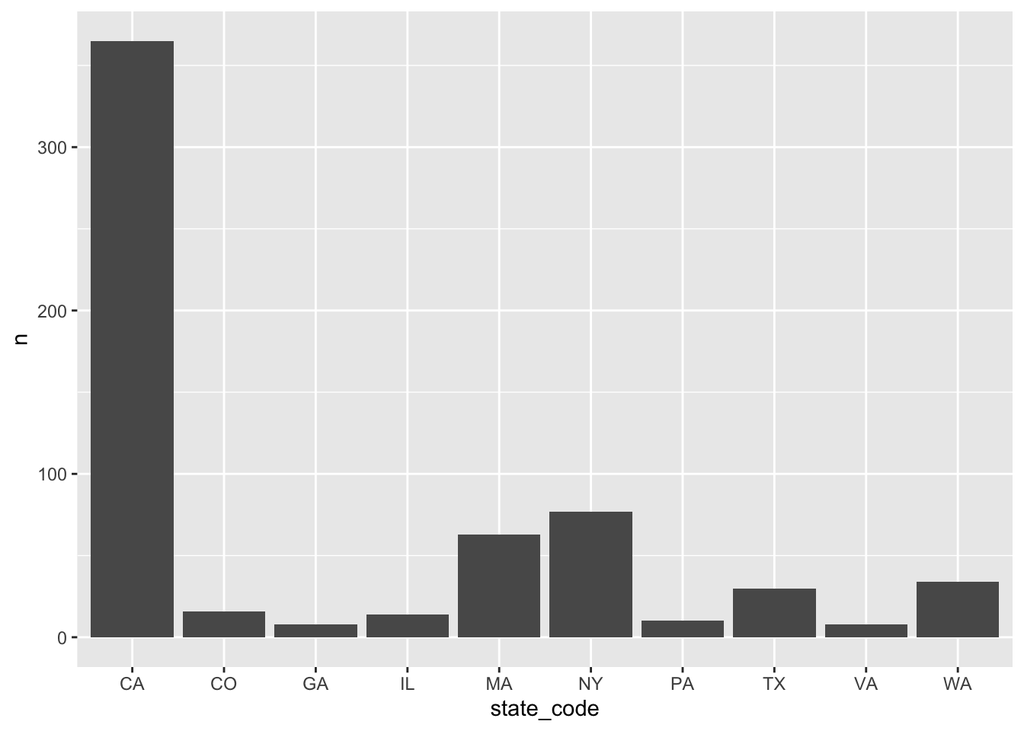

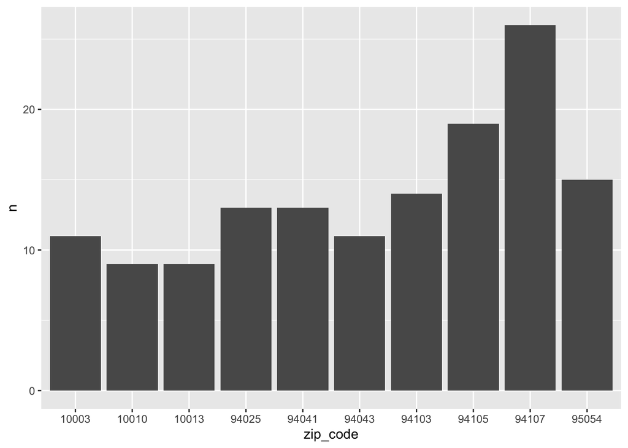

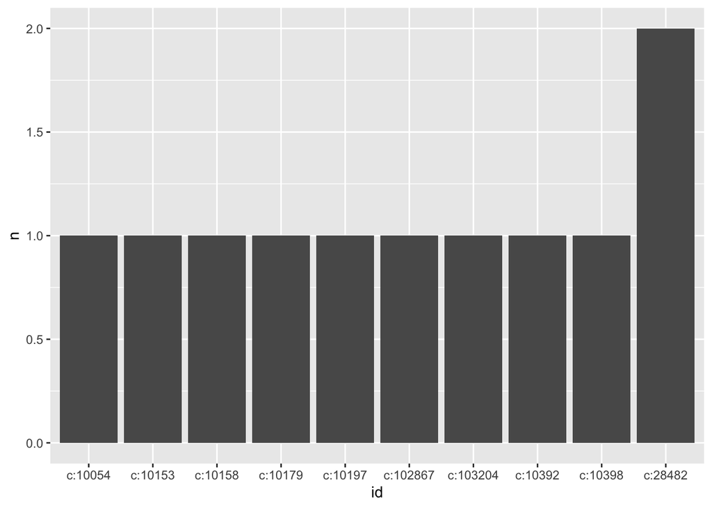

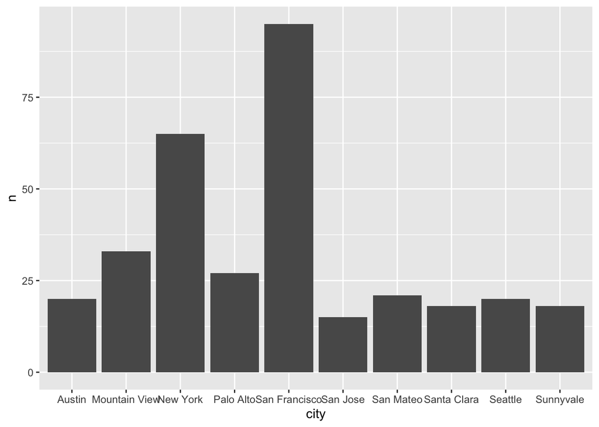

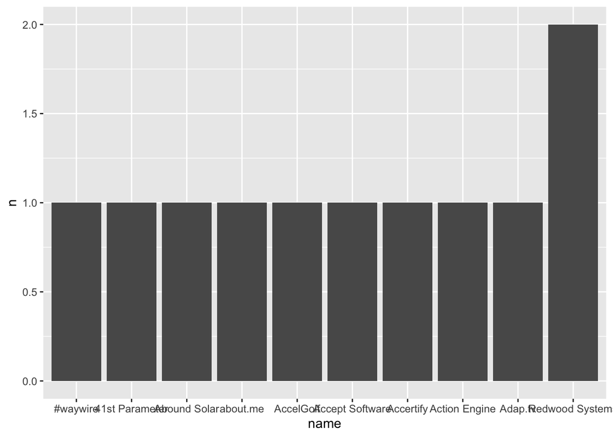

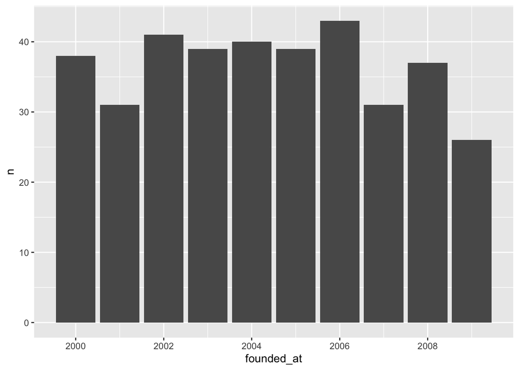

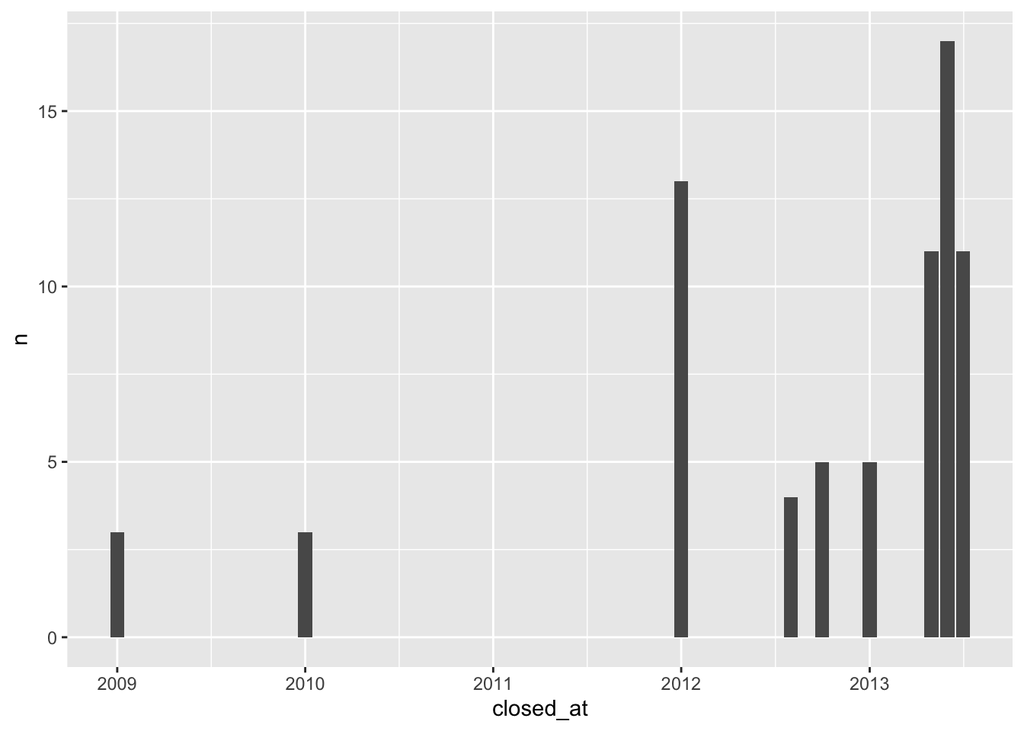

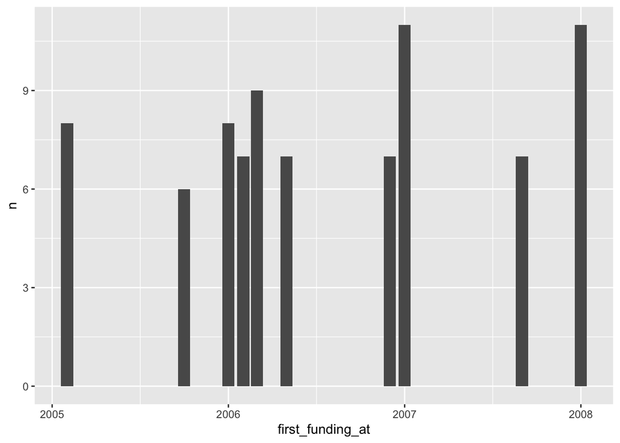

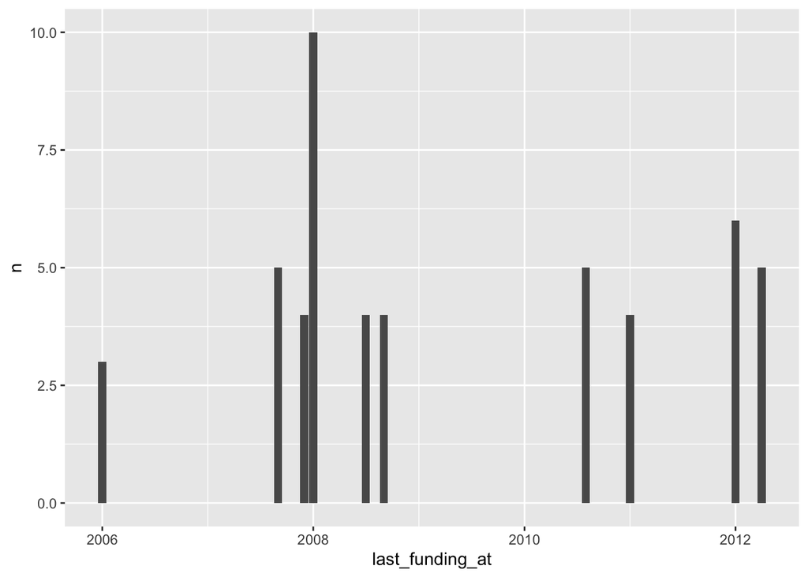

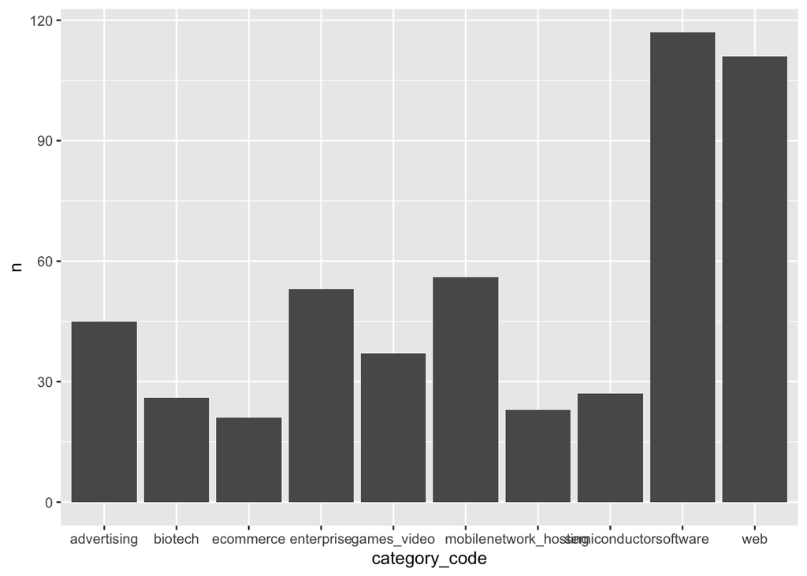

```r
n <- 10  # Number of most frequent levels to show
for (i in feat_cat){

  counts <- df_train %>% count(!!sym(i)) %>% arrange(desc(n)) %>% head(n)

  p <- ggplot(counts, aes_string(x=i, y="n")) +
    geom_bar(stat="identity")

  plot(p)
}
```

### 2.3.3 Numerical Features

After analyzing single categorical features, the same is done for numerical features.

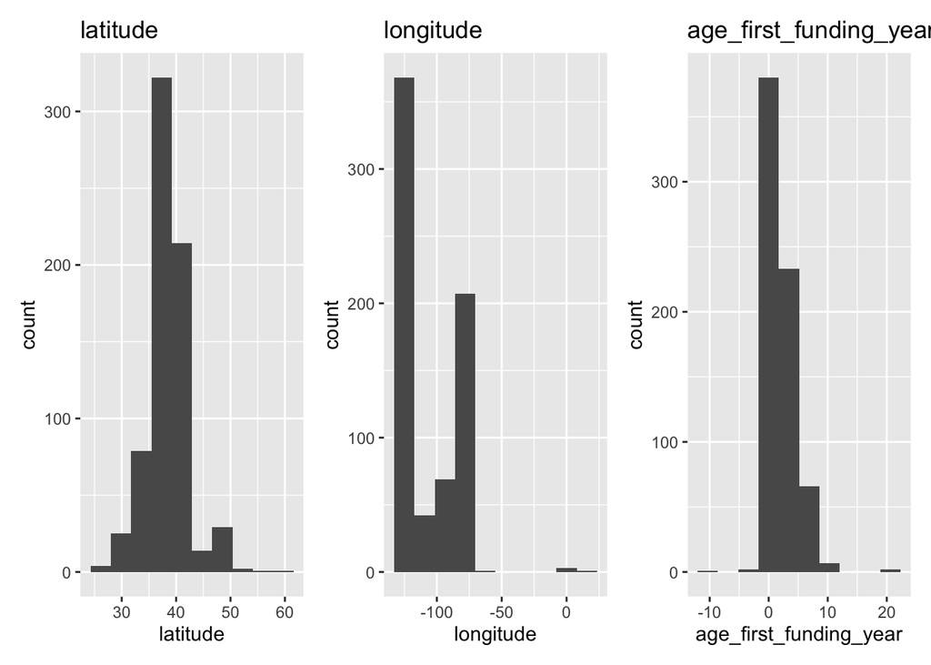

```r
# Removing one hot encoded features
df_numeric <- df_train %>%
  select(all_of(feat_num))
df_numeric <- df_numeric %>%
  select(-is_CA, -is_NY, -is_MA, -is_TX, -is_otherstate, -is_software, -is_web, -is_mobile, -is_enterprise, -is_advertising, -is_gamesvideo, -is_ecommerce, -   is_biotech, -is_consulting, -is_enterprise, -is_othercategory, -has_VC, -has_angel, -has_roundA, -has_roundB, -has_roundC, -has_roundD, -is_top500)

# Create histograms using ggplot2
hist_list <- lapply(names(df_numeric), function(col) {
  ggplot(df_numeric, aes(x = .data[[col]])) +
  geom_histogram(bins = 10) +
  ggtitle(paste0(col))
})

# Arrange histograms in a grid
library(patchwork)
hist_list[[1]] + hist_list[[2]] + hist_list[[3]] + plot_layout(ncol = 3)
```

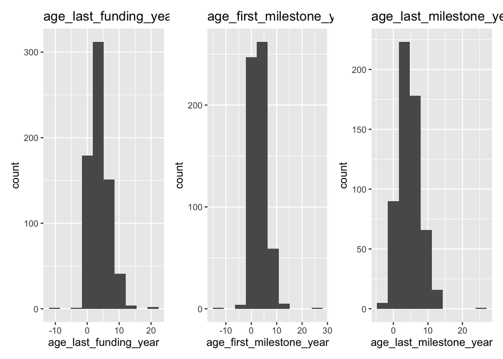

```r
hist_list[[4]] + hist_list[[5]] + hist_list[[6]] + plot_layout(ncol = 3)
```

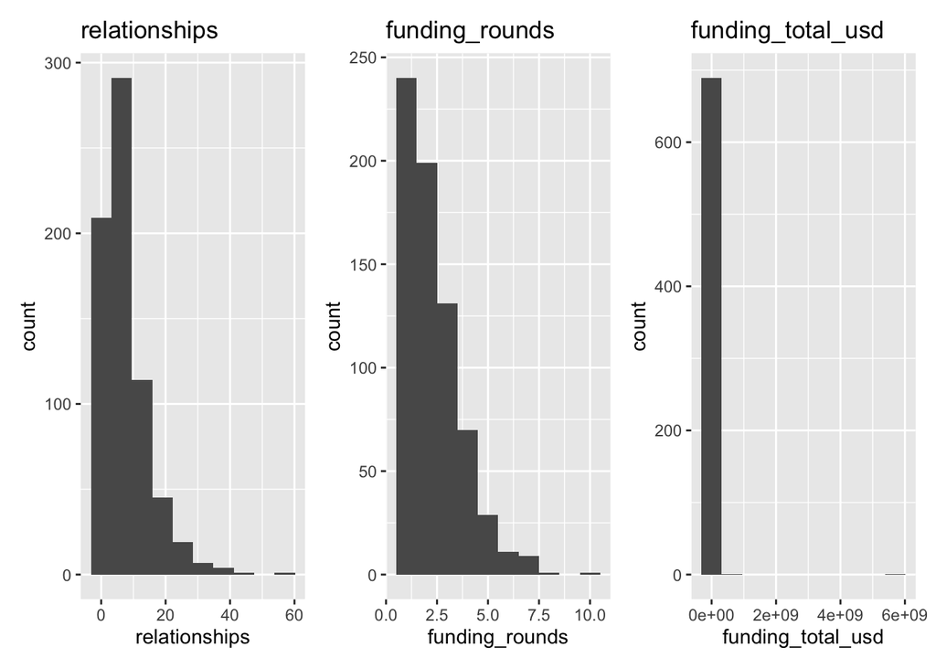

```r
hist_list[[7]] + hist_list[[8]] + hist_list[[9]] + plot_layout(ncol = 3)
```

The histogram for longitude verifies that the maximum value is an outlier.There are two local maxima, one around -120° and another one at around -80°, these are the West and East Coast of the United States. The latitude of most startups is between 35° an 40°, the North and South of the United States. For age_first_funding_year, age_last_funding_year, age_first_milestone_year and age_last_milestone_year, the assumption of outlier below 0 and higher than 10 is confirmed as well. The distributions of relationships and funding_rounds look as I imagined them. The maximum of funding_total_usd is an even more significant outlier than expected, as the hitsogram only has one visible bin on the very left. This needs to be removed.

### 2.3.4 Relationships

The fist realtionship analyized is between the numerical features. Correlation is a positive or negative linear relationship between two variables. +1 and -1 indicate the highest possible linear correlation and 0 indicated no correlation. As our label is categorical, it is not posisbel to identify correlations to it with this method. But if the correlations between features in the model is too high, this might lead to overfitting. This method helps to identify those and evaluate which to include in the mdoel in the feature engineering chapter.

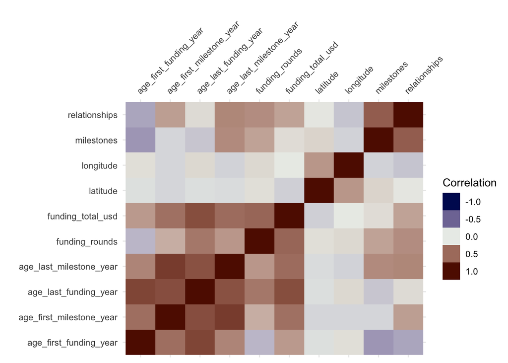

```r
df_numeric %>%
  vis_cor(cor_method = "spearman", na_action = "pairwise.complete.obs")
```

There is a strong positive correlation (dark brown) between age_first_funding_year and age_last_funding_year as well as age_first_milestone_year and age_last_milestone_year. Another strong positive correlation exists between funding_total_usd and age_last_funding_year. Also milestones and relationships are positively correlated. There are no strong negative correlation, the strongest is between milestones and age_first_funding_year.

To make these results more presice, now the numbers of correlation are displayed. In addition we have a look at the graphs of the relationships to identify any non-lineat relationships as well.

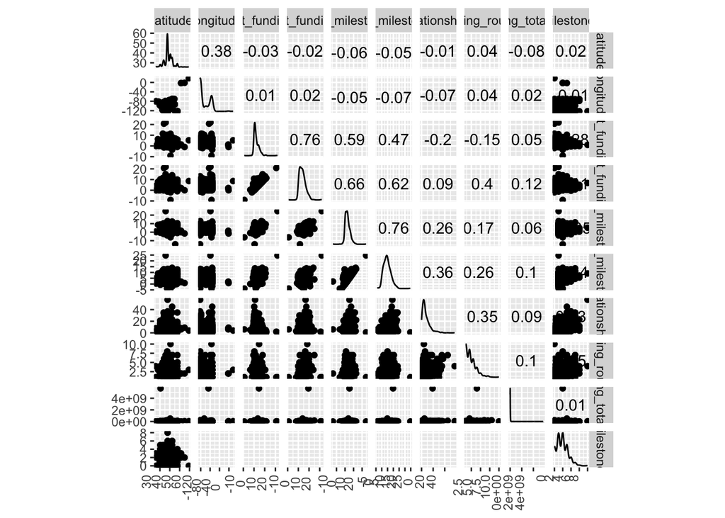

```r
df_numeric %>%
  ggscatmat() +
  theme(axis.text.x = element_text(angle = 90, vjust = -1))
```

There are no non-linear relationshsips identified. The strong positive correlation between the funding and milestone age variables is visible in the scatterplots and verified through correlations > 0.5.

At this, point further correlations between categorical and numerical features area visualized. Do successful startups have more or less relationships?

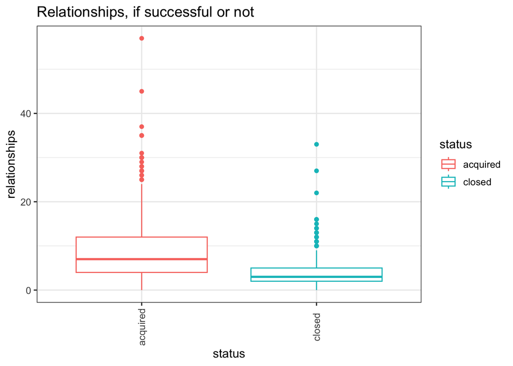

```r
df_train %>%
  ggplot(aes(x = status, y = relationships, color = status)) +
  geom_boxplot() +
  labs(title = "Relationships, if successful or not") +
  theme_bw(base_size = 12) +
  theme(axis.text.x = element_text(angle = 90, vjust = 0.5))
```

Expanding on this. How is the amount of funding_rounds related to the status and relationships?

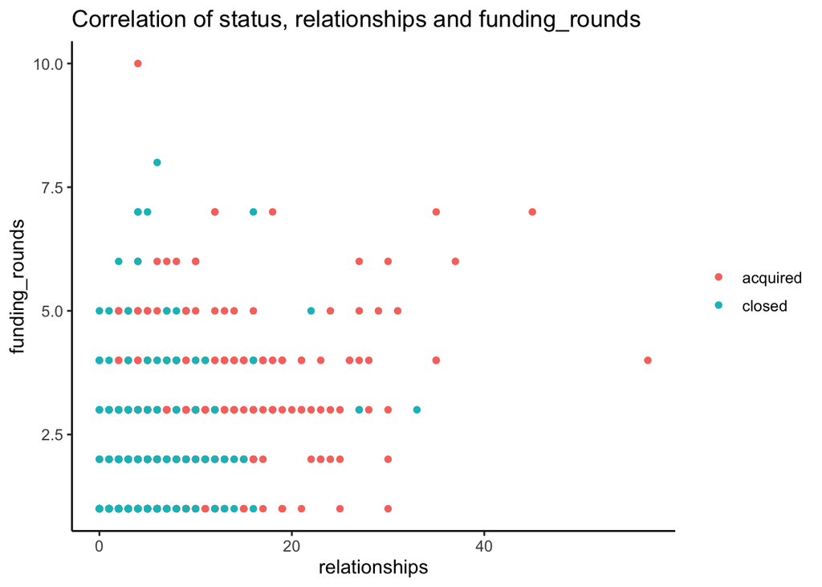

```r
df_train %>%
  ggplot(aes(x = relationships, y = funding_rounds, group = status, color = status)) +
  geom_point() +
  theme_classic(base_size = 12) +
  ggtitle("Correlation of status, relationships and funding_rounds") +
  theme(legend.title = element_blank())
```

Acquired startups have more relationships and go through more funding rounds.

As discusessed ealsier, it is easier to visualize longitude and latititude than talking about their values. On the map the locations of startups are visualized and by color their are distiguished by status.

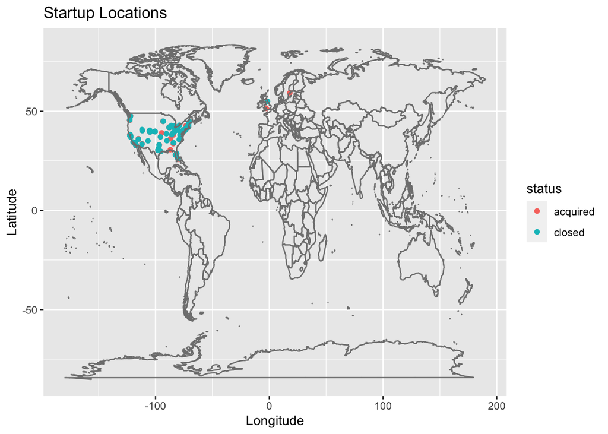

```r
world_map <- map_data("world")

ggplot(df_train, aes(x = longitude, y = latitude, color = status)) +
  geom_point() +
  geom_path(data = world_map, aes(x = long, y = lat, group = group), color = "gray50") +
  labs(x = "Longitude", y = "Latitude", title = "Startup Locations")
```

There are a few startups located in Europe, but most are located in the US. Many acquired startups are rather on the East of the US.

Another map visualization.

```r
library(ggmap)
```

```
## ℹ Using `zoom = 4`
```

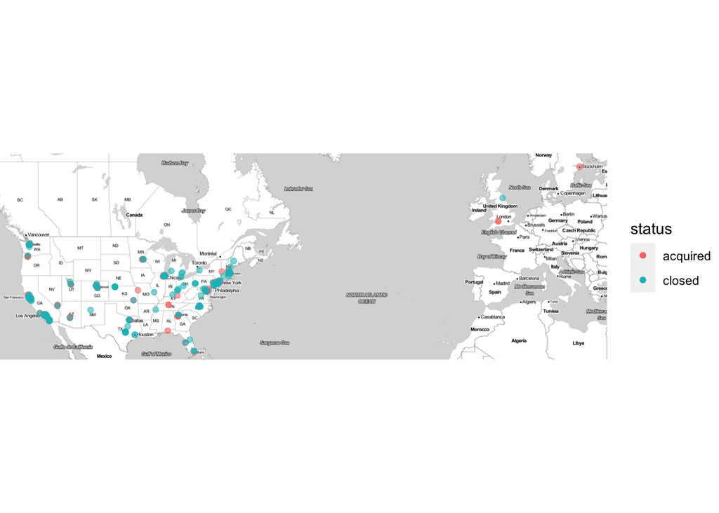

```r
qmplot(x = longitude,
       y = latitude,
       data = df_train,
       geom = "point",
       color = status,
       alpha = 0.4) +
  scale_alpha(guide = 'none') # don't show legend for alpha
```

Do successful startups have their first funding round earlier or later?

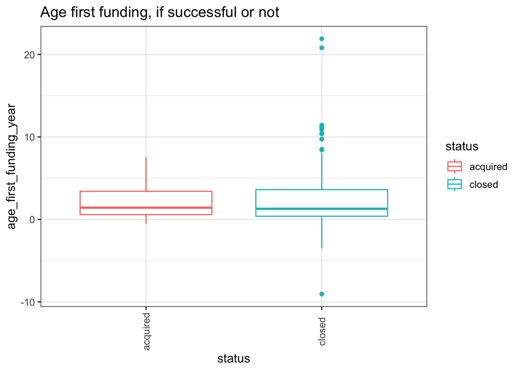

```r
df_train %>%
  ggplot(aes(x = status, y = age_first_funding_year, color = status)) +
  geom_boxplot() +
  labs(title = "Age first funding, if successful or not") +
  theme_bw(base_size = 12) +
  theme(axis.text.x = element_text(angle = 90, vjust = 0.5))
```

The first funding round happen around the same time for most startups, whether successful or not.

## 2.4 Define Schema

As a single dataframe is used for this data science lifecycle, the need for a schema is low. As the quality of the data seems quite high and the dataframe is well structures, no schema is defined for this project.

## 2.5 Anomaly Detection

An anomaly that was identified in the data analysis is that there is one duplicate startup by name and id. This should be removed.

```r
# remove duplicate rows
train_data <- distinct(train_data)
```

Other anomalies are missing values and outliers, which are handled now.

### 2.5.1 Missing Values

At first, we need to find out how many missing values there are in which column. They will be fixed in the feature engineering recipe later on.

```r
is.na(train_data) %>%
    colSums()
```

```
##               state_code                 latitude                longitude
##                        0                        0                        0
##                 zip_code                       id                     city
##                        0                        0                        0
##                     name               founded_at                closed_at
##                        0                        0                      442
##         first_funding_at          last_funding_at   age_first_funding_year
##                        0                        0                        0
##    age_last_funding_year age_first_milestone_year  age_last_milestone_year
##                        0                      112                      112
##            relationships           funding_rounds        funding_total_usd
##                        0                        0                        0
##               milestones                    is_CA                    is_NY
##                        0                        0                        0
##                    is_MA                    is_TX            is_otherstate
##                        0                        0                        0
##            category_code              is_software                   is_web
##                        0                        0                        0
##                is_mobile            is_enterprise           is_advertising
##                        0                        0                        0
##            is_gamesvideo             is_ecommerce               is_biotech
##                        0                        0                        0
##            is_consulting         is_othercategory                   has_VC
##                        0                        0                        0
##                has_angel               has_roundA               has_roundB
##                        0                        0                        0
##               has_roundC               has_roundD                is_top500
##                        0                        0                        0
##                   status
##                        0
```

There are 442 missing values in closed_at, probably because all successful startups haven’t closed, thus they don’t have a closing date. This feature is too tightly related to the prediction and thus needs to be removed for the model. There are 112 missing values each for age_first_milestone_year and age_last_milestone year. As there are only a couple hundred startups in the dataframe, the ratio of missing values is to high to simply delete these rows. Instead, the missing values will be replaced by the median. Having this many values replaced, the feature importance for the model will decrease.

### 2.5.2 Outlier Detection

In the data analysis, a few possible outliers have been called out and are investigated now.

```sql
SELECT COUNT(*)
FROM df_train
WHERE longitude > -50;
```

1 records

| COUNT(*) |
| --- |
| 4 |

There are 4 startups in Europe in the dataframe. This is very small amount, but as this dataframe will be expanded in the future through information of our customers, all locations are included from the beginning.

Another outlier are the negative first and last funding age. How many of those are there in the dataframe?

```sql
SELECT name, age_first_funding_year, age_last_funding_year
FROM df_train
WHERE age_first_funding_year < 0 OR age_last_funding_year < 0;
```

Displaying records 1 - 10

| name | age_first_funding_year | age_last_funding_year |
| --- | --- | --- |
| Behavio | -0.0301 | -0.0301 |
| MoPub | -0.0219 | 2.0329 |
| GrandCentral | -0.2466 | -0.2466 |
| Powerset | -0.4192 | 0.6658 |
| Zing Systems | -0.4986 | -0.4137 |
| PayDivvy | -0.1370 | 3.1452 |
| Where | -0.0027 | 5.0055 |
| Storify | -0.4466 | 1.1479 |
| Surphace | -0.1671 | 0.9151 |
| The Huffington Post | -0.0219 | 5.2329 |

There are 35 startups with either a negative first or last funding age. These are too many to remove them. If this projected was extended, the root cause for a negative funding age should be identified. Another realization from this analysis is that all startups that have a negative last funding age also have a negative first funding age.

The first and last funding age were rather left skewed, thus teh higher values are evaluated to be outliers now.

```sql
SELECT name, age_first_funding_year, age_last_funding_year
FROM df_train
WHERE age_first_funding_year > 5 OR age_last_funding_year > 5;
```

Displaying records 1 - 10

| name | age_first_funding_year | age_last_funding_year |
| --- | --- | --- |
| TriCipher | 5.1260 | 9.9973 |
| ClairMail | 1.6466 | 6.7616 |
| Stratavia | 4.6658 | 8.9973 |
| MeeVee | 4.5918 | 7.1726 |
| Lockdown Networks | 4.1534 | 5.1671 |
| Peer39 | 0.0000 | 5.9041 |
| Mashery | 0.6712 | 6.2329 |
| Handmark | 5.2027 | 6.1890 |
| SchemaLogic | 4.0466 | 9.3041 |
| Intela | 3.9616 | 6.5205 |

The higher first and last funding age is no outlier, one third of the startups have either their first or last funding after 5 years.

Another outlier are the negative first and last milestone age. How many of those are there in the dataframe?

```sql
SELECT name, age_first_milestone_year, age_last_milestone_year
FROM df_train
WHERE age_first_milestone_year < 0 OR age_last_milestone_year < 0;
```

Displaying records 1 - 10

| name | age_first_milestone_year | age_last_milestone_year |
| --- | --- | --- |
| MeeVee | -0.4986 | 12.6795 |
| Qwiki | -0.5863 | 3.7534 |
| Sentrigo | -0.7479 | 4.4767 |
| GrandCentral | -0.4082 | 7.4548 |
| Meridian | -14.1699 | 2.2082 |
| Tracelytics | -0.0822 | 1.7205 |
| Zing Systems | -0.4986 | 5.7699 |
| Socialize | -2.4986 | 4.7205 |
| PayDivvy | -2.0932 | 4.4082 |
| Airwide Solutions | -1.9151 | -1.9151 |

Just as negative first and last funding age, there are 35 startups that either have a negative first or last milestone age. Are those the same startups?

```sql
SELECT COUNT(*)
FROM df_train
WHERE age_first_milestone_year < 0 OR age_last_milestone_year < 0 OR age_first_funding_year < 0 OR age_last_funding_year < 0;
```

1 records

| COUNT(*) |
| --- |
| 62 |

The startups having negative milestone and funding ages differ mostly. If it were the same, the count would be 35.

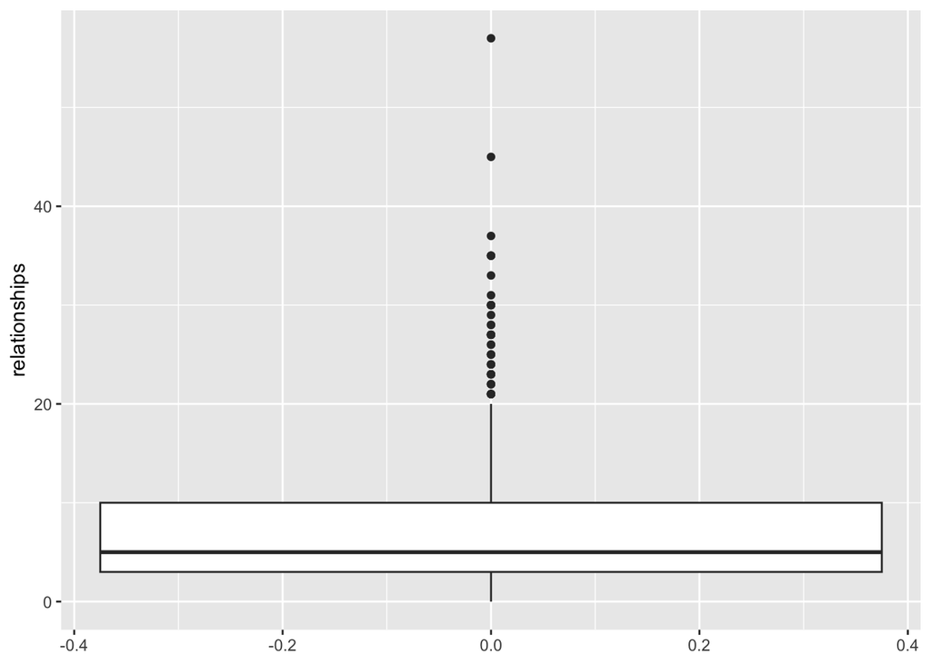

```r
# boxplot relationships
df_train %>%
  ggplot(aes(y = relationships)) +
  geom_boxplot()
```

Startups having more than 20 relationships are outliers.

The maximum fundinng_total_usd is tremendously higher than all other funding amounts. Should this be removed?

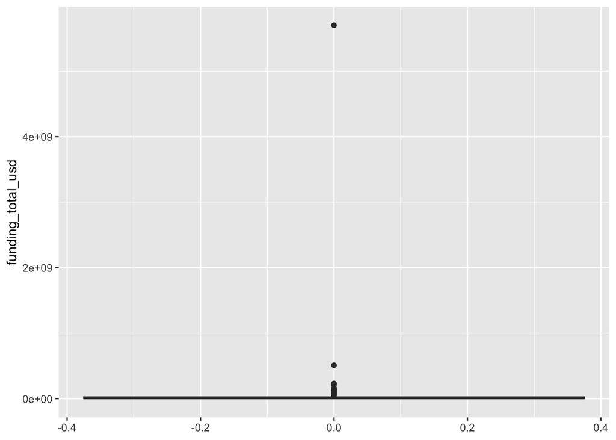

```r
# boxplot funding_total_usd
df_train %>%
  ggplot(aes(y = funding_total_usd)) +
  geom_boxplot()
```

The other outliers are way lower than the maximum funding_total_usd, that is why the startups with extremely high funding have to be removed from the dataframe.

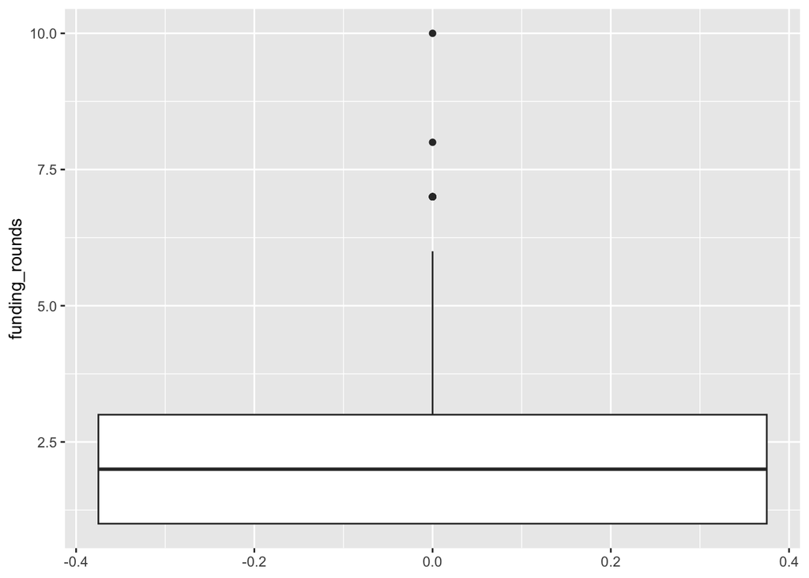

```r
# boxplot funding_rounds
df_train %>%
  ggplot(aes(y = funding_rounds)) +
  geom_boxplot()
```

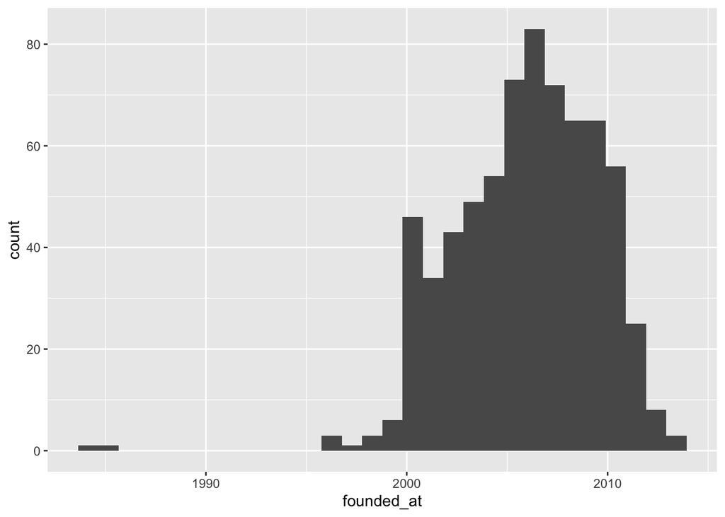

```r
# histogram founded_at
df_train %>%
  ggplot(aes(x = founded_at)) +
  geom_histogram()
```

There is a huge gap between the earliest founded_at and the next in the lat 1990s.

## 2.6 Feature Engineering

Feature engineering is the process of using domain knowledge to extract meaningful features from the data. The goal of this process is to keep those features that improve the predictions from our model. For this a pipeline is created that included the standardization of numeric features and one hot encoding of catgeorical features. As the categories and states are already one hot encoded, their categorical featured need to be removed. The anomalies, like outliers, missing values or wrong data types, will be fixed in the recipe in the next chapter.

# 3 Model

This chapter describes the creation of a model to predict the success of a startup. Several classification algorithms are optimized and compared to select the best performing model.

## 3.2 Model Training & Tuning

### 3.2.1 Feature Selection

At first, we need to decide which features we want to include in our model. As identified in the correlation matrix, there is a strong positive linear correlation between the first and last funding and milestone age of startups. These highly correlated features are removed and this is included in the recipe of Feature Engineering already.

```r
df_rec <-
  recipe(status ~ ., data = train_data) %>%
  step_rm(closed_at, state_code, category_code, latitude, longitude, zip_code, city, name, id) %>% #remove unnecessary columns
  step_impute_median(age_first_milestone_year, age_last_milestone_year) %>% #replace NaN with median
  step_naomit(everything(), skip = TRUE) %>% #remove rows with NaN values (only as double check)
  step_mutate(founded_at = as.numeric(founded_at)) %>% #date to numeric
  step_mutate(first_funding_at = as.numeric(first_funding_at)) %>%
  step_mutate(last_funding_at = as.numeric(last_funding_at)) %>%
  step_corr(all_predictors(), threshold = 0.7, method = "spearman") %>% #remove highly correlated
  #step_outliers_maha(all_numeric(), -all_outcomes()) %>%
  #step_outliers_lookout(all_numeric(),-contains(r"(.outliers)"),-all_outcomes()) %>%
  #step_outliers_remove(contains(r"(.outliers)")) %>% # remove outliers
  step_zv(all_numeric(), -all_outcomes()) %>% #remove all numeric that have zero variance
  step_normalize(all_numeric(), -all_outcomes()) #standardize numeric features
```

```r
# bake recipe
prepped_data <-
  df_rec %>% # use the recipe object
  prep() %>% # perform the recipe on training data
  juice() # extract only the preprocessed dataframe
```

Could not make outlier removel work, which could have a negative impact on the model performance.

From the training data another split is performed to create validation data. This is used to verify the model before adding new data to avoid overfitting of the model to the training data.

```r
# crossvalidation
set.seed(100)

cv_folds <-
 vfold_cv(train_data,
          v = 5,
          strata = status)
```

### 3.2.2 Training & Hyperparameter Tuning

In the first phase of the model process, the initial models are generated and their performance is compared during model evaluation. Besides the model specification, workflows need to be created to combine the data preparation recipe with the model. As a third step, our validation set (cv_folds) is fitted to estimate the performance of our models afterwards.

```r
# Logistic Regression
# model
log_spec <- # your model specification
  logistic_reg() %>%  # model type
  set_engine(engine = "glm") %>%  # model engine
  set_mode("classification") # model mode

# workflow pipeline
log_wflow <- # new workflow object
 workflow() %>% # use workflow function
 add_recipe(df_rec) %>%   # use the new recipe
 add_model(log_spec)   # add your model spec

# fit model with crossvalidation
log_res <-
  log_wflow %>%
  fit_resamples(
    resamples = cv_folds,
    metrics = metric_set(yardstick::recall, yardstick::precision, accuracy),
    control = control_resamples(save_pred = TRUE)
    )
```

```
## → A | warning: prediction from a rank-deficient fit may be misleading
```

[output not shown]

```r
# Decision Tree
# model
xgb_spec <-
  boost_tree() %>%
  set_engine("xgboost") %>%
  set_mode("classification")

# workflow pipeline
xgb_wflow <-
 workflow() %>%
 add_recipe(df_rec) %>%
 add_model(xgb_spec)

# fit model with crossvalidation
xgb_res <-
  xgb_wflow %>%
  fit_resamples(
    resamples = cv_folds,
    metrics = metric_set(yardstick::recall, yardstick::precision, accuracy),
    control = control_resamples(save_pred = TRUE)
    )
```

### 3.2.3 Evaluation

Now the results of the models are compared and their performance evaluated to decide which model is the best for our startup success prediction use case.

Average performance over all folds for logistic regression.

```r
log_res %>%
  collect_metrics(summarize = TRUE)
```

```
## # A tibble: 3 × 6
##   .metric   .estimator  mean     n std_err .config
##   <chr>     <chr>      <dbl> <int>   <dbl> <chr>
## 1 accuracy  binary     0.731     5 0.0142  Preprocessor1_Model1
## 2 precision binary     0.760     5 0.0130  Preprocessor1_Model1
## 3 recall    binary     0.855     5 0.00501 Preprocessor1_Model1
```

We have a closer look at three metrics: Accuracy, precision and recall. The accuracy rates the overall correct classifications. Precision describes how much of the samples, which have been classified as positive are actual positive. And recall describes how much of the true positive samples has been classified as positive.

The logistic regression model has an accuracy of 73%. 76% of the startups that it predicted to be successful, are actually successful and 85% of true positive samples habe been classified as positive.

Performance for every single fold for logistic regression.

```r
log_res %>%
  collect_metrics(summarize = FALSE)
```

```
## # A tibble: 15 × 5
##    id    .metric   .estimator .estimate .config
##    <chr> <chr>     <chr>          <dbl> <chr>
##  1 Fold1 recall    binary         0.867 Preprocessor1_Model1
##  2 Fold1 precision binary         0.757 Preprocessor1_Model1
##  3 Fold1 accuracy  binary         0.734 Preprocessor1_Model1
##  4 Fold2 recall    binary         0.844 Preprocessor1_Model1
##  5 Fold2 precision binary         0.768 Preprocessor1_Model1
##  6 Fold2 accuracy  binary         0.734 Preprocessor1_Model1
##  7 Fold3 recall    binary         0.854 Preprocessor1_Model1
##  8 Fold3 precision binary         0.752 Preprocessor1_Model1
##  9 Fold3 accuracy  binary         0.725 Preprocessor1_Model1
## 10 Fold4 recall    binary         0.865 Preprocessor1_Model1
## 11 Fold4 precision binary         0.802 Preprocessor1_Model1
## 12 Fold4 accuracy  binary         0.775 Preprocessor1_Model1
## 13 Fold5 recall    binary         0.843 Preprocessor1_Model1
## 14 Fold5 precision binary         0.721 Preprocessor1_Model1
## 15 Fold5 accuracy  binary         0.686 Preprocessor1_Model1
```

The range for all metrics is not too big, bur rather similar for every model.

Now, we obtain the actual model predictions to compare the amount of correct and false predictions.

```r
log_pred <-
  log_res %>%
  collect_predictions()
```

A confusion matrix is created to compare the amounts of predictions. How to read a classification matrix:

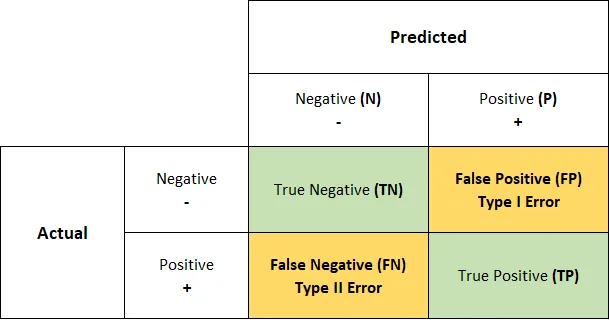

From these numbers, various metrics can be calculated.

Accuracy: The rate of overall correct classifications.

$$ACC=\frac{TP+TN}{FP+FN+TP+TN}$$

Precision: How much of the samples, which have been classified as positive are actual positive

$$PRE=\frac{TP}{FP+TP}$$

Recall: How much of the true positive samples has been classified as positive

$$REC=\frac{TP}{FN+TP}$$

For the prediction of startup success, we want the number of False Positives to be as little as possible, because these mean an investment gone wrong and lots of monex being lost for the investors and thus focus on precision.

```r
log_pred %>%
  conf_mat(status, .pred_class)
```

```
##           Truth
## Prediction acquired closed
##   acquired      382    121
##   closed         65    123
```

The confusion matrix can also be visualized to make reading it easier.

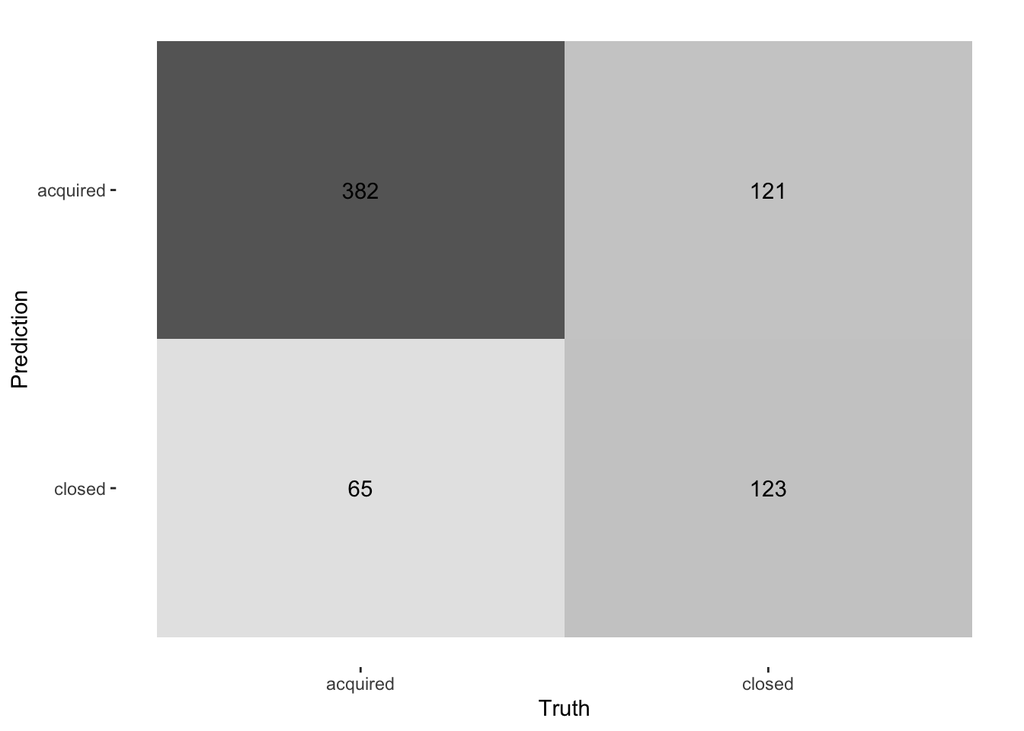

```r
log_pred %>%
  conf_mat(status, .pred_class) %>%
  autoplot(type = "heatmap")
```

382 startups are True Positives, as they have been predicted to be acquired and have also been acquired in reality. On the other hand, 123 startups that closed have also been predicted to close, those are the True Negatives. There are 65 False Negatives, that have been acquired, but were predicted to close. The fourth kind are the False Positives, those have closed in reality, but were predicted to be acquired. There are 121 False Positives in this logistic regression and this is the number that should be as low as possible.

Now, we will have a look at the metrics of the other algorithm - Gradient Bossted Trees.

```r
xgb_res %>%
  collect_metrics(summarize = TRUE)
```

```
## # A tibble: 3 × 6
##   .metric   .estimator  mean     n std_err .config
##   <chr>     <chr>      <dbl> <int>   <dbl> <chr>
## 1 accuracy  binary     0.760     5  0.0134 Preprocessor1_Model1
## 2 precision binary     0.779     5  0.0137 Preprocessor1_Model1
## 3 recall    binary     0.879     5  0.0123 Preprocessor1_Model1
```

The Gradient Boosted Tree has an accuracy of 76%, recall of 88% and most importantly a precision of 78%.

Looking in more detail at the correct and false predictions of the Gradient Boosted Trees.

```r
xgb_pred <-
  xgb_res %>%
  collect_predictions()
```

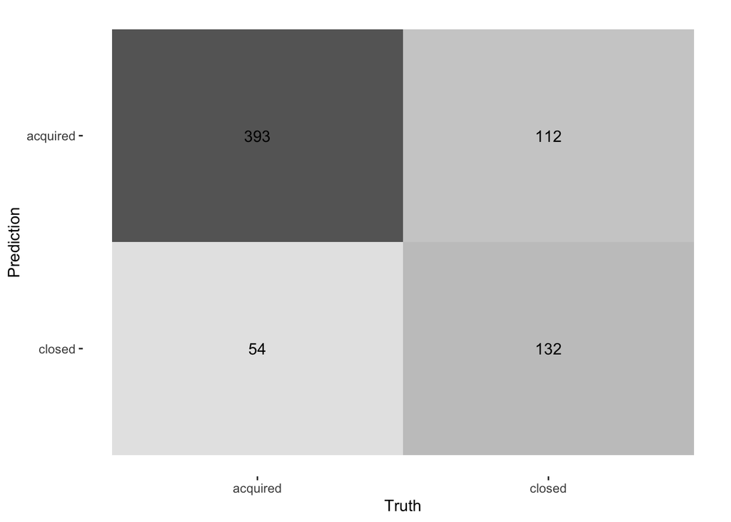

```r
xgb_pred %>%
  conf_mat(status, .pred_class) %>%
  autoplot(type = "heatmap")
```

There are 112 False Positives, so startups that have been predicted to be acquired, but actually closed.

Instead of looking at the metrics one by one, we compare them now.

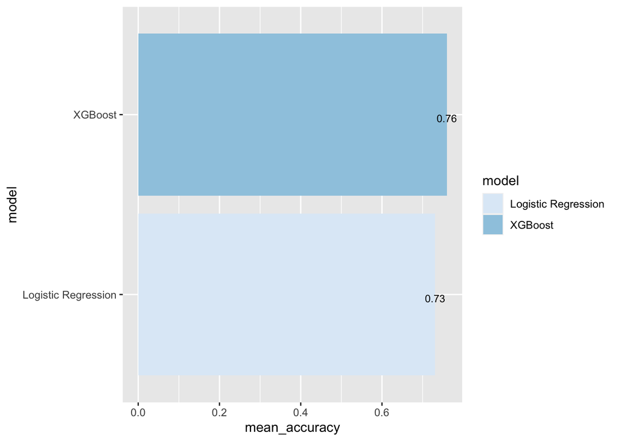

```r
# compare models
log_metrics <-
  log_res %>%
  collect_metrics(summarise = TRUE) %>%
  mutate(model = "Logistic Regression") # add the name of the model to every row

xgb_metrics <-
  xgb_res %>%
  collect_metrics(summarise = TRUE) %>%
  mutate(model = "XGBoost")

# create dataframe with all models
model_compare <- bind_rows(log_metrics,
                           xgb_metrics)

# change data structure
model_comp <-
  model_compare %>%
  select(model, .metric, mean, std_err) %>%
  pivot_wider(names_from = .metric, values_from = c(mean, std_err))

# show mean accuracy for every model
model_comp %>%
  arrange(mean_accuracy) %>%
  mutate(model = fct_reorder(model, mean_accuracy)) %>% # order results
  ggplot(aes(model, mean_accuracy, fill=model)) +
  geom_col() +
  coord_flip() +
  scale_fill_brewer(palette = "Blues") +
   geom_text(
     size = 3,
     aes(label = round(mean_accuracy, 2)),
     vjust = 1
  )
```

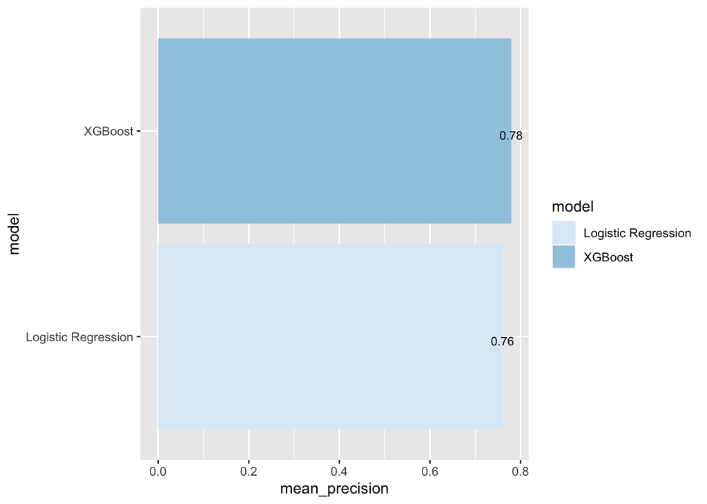

```r
# show mean precision per model
model_comp %>%
  arrange(mean_precision) %>%
  mutate(model = fct_reorder(model, mean_precision)) %>%
  ggplot(aes(model, mean_precision, fill=model)) +
  geom_col() +
  coord_flip() +
  scale_fill_brewer(palette = "Blues") +
     geom_text(
     size = 3,
     aes(label = round(mean_precision, 2)),
     vjust = 1
  )
```

The accuracy and precision of the Decision Tree are a little higher and thus, this is the model with the best performance. The objective for a good model, is supposed to be 80% for accuracy and precision and those are not quite reached, but at it is close.

## 3.3 Evaluate Model

The best model is evaluated on its errors to understand why it makes them and how to fix them.

```r
# make predictions
#assess_res <- collect_predictions(xgb_res)

# obtain the 10 wrongest predictions
#wrongest_predictions <-
#  assess_res %>%
#  mutate(residual = status - .pred) %>%
#  arrange(desc(abs(residual))) %>%
#  slice_head(n = 10)

# take a look at the observations
#errors <-
#  train_data %>%
#  dplyr::slice(wrongest_prediction$.row)
```

Does not seem to work, cannot find a solution to the error.